# Online campaigns analysis: ROAS visualizations & recommendations

Part three.

Sebastián Huneeus https://shuneeus.github.io/  
2021-05-18

```r
library(tidyverse)
library(distill)
```

```r
app_roas<-read_csv("outputs/app_roas.cvs")
web_roas<-read_csv("outputs/web_roas.cvs")
```

As previously found, there are four campaigns, each combining different channels and regions. Calculating the ROAS KPI, it is possible to detect the best performing campaigns and the worst-performing.

### App channel ROAS

The following graph displays the ROAS of the three App campaigns, sorted by regions. The overall performance of the app channel ROAS is 0.91. The graphic shows, however, that campaign ID 37981, in North America, is underperforming considerably with the lowest ROAS of 0.37.

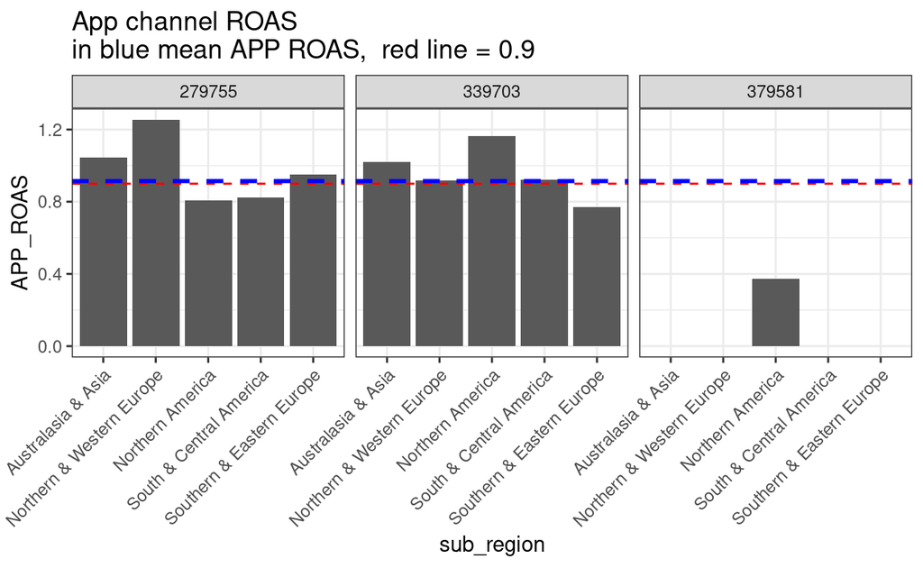

```r
app_roas %>%
  ggplot(aes(x= sub_region, y = APP_ROAS )) + geom_col() +
  facet_grid(. ~campaign_id) +
  theme_bw() +
  theme(axis.text.x = element_text(angle = 45, hjust = 1)) +
  geom_hline(yintercept=.9, linetype="dashed", color = "red") +
  geom_hline(yintercept=mean(app_roas$APP_ROAS), linetype="dashed",
                color = "blue", size=1) +
  ggtitle("App channel ROAS \nin blue mean APP ROAS,  red line = 0.9")
```

### Web channel ROAS

The overall performance of the web campaig is 0.8. In terms of regions, the Northern & Western Europe region had the a weakest performance (0.62). On the other side, Australasia & Asia had the stronges ROAS of 1.02.

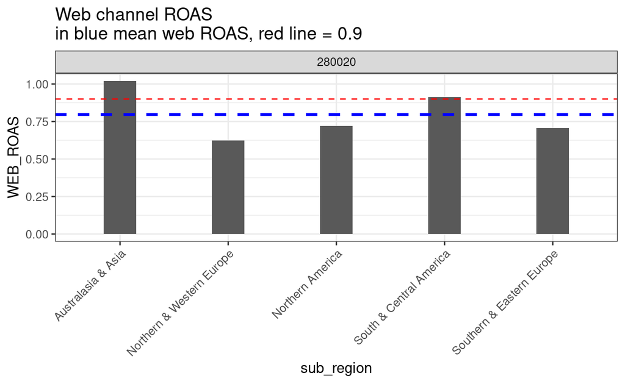

```r
web_roas %>%
  ggplot(aes(x= sub_region, y = WEB_ROAS )) + geom_col(width = .3) +
  facet_grid(. ~campaign_id) +
  theme_bw() +
  theme(axis.text.x = element_text(angle = 45, hjust = 1)) +
  geom_hline(yintercept=.9, linetype="dashed", color = "red") +
  geom_hline(yintercept=mean(web_roas$WEB_ROAS), linetype="dashed",
                color = "blue", size=1) +
  ggtitle("Web channel ROAS \nin blue mean web ROAS, red line = 0.9")
```

## General recommendations for management

There are three main patterns found in the analysis:

1. That App campaigns perform 13,75% better than web ads.
2. Web campaigns have an average ROAS of 0.8, with a minimum of 0.62 (Northern & Western Europe) and a maximum ROAS value of 1.02 (Australasia & Asia).
3. App campaigns had an average of 0.91, with a minimum ROAS of 0.38 (Campaign id 379581 - Northern America ) and a maximum of 1.25 (Campaign id 279755 - Northern & Western Europe).

Recommendations:

1. Increase spending in App campaigns. Focus spending on regions more responsive to App advertising such as “Northern & Western Europe” and “Australasia & Asia.”
2. Decrease spending in the lower-performing regions, specifically in the “Northern & Western Europe” and in “Southern & Eastern Europe.”